```python
%matplotlib inline
```

# Final Project Notebook

DS 5001 Text as Data

# Metadata

- Full Name: Lino De Ros
- Userid: xcm7zb
- GitHub Repo URL: https://github.com/lderos/DS-5001-Final-Project
- UVA Box URL: https://virginia.box.com/s/c8eq1i61whl6dek6izpngtyxpxw5z6oi

# Overview

The goal of the final project is for you to create a **digital analytical edition** of a corpus using the tools, practices, and perspectives you’ve learning in this course. You will select a corpus that has already been digitized and transcribed, parse that into an F-compliant set of tables, and then generate and visualize the results of a series of fitted models. You will also draw some tentative conclusions regarding the linguistic, cultural, psychological, or historical features represented by your corpus. The point of the exercise is to have you work with a corpus through the entire pipeline from ingestion to interpretation.

Specifically, you will acquire a collection of long-form texts and perform the following operations:

- **Convert** the collection from their source formats (F0) into a set of tables that conform to the Standard Text Analytic Data Model (F2).
- **Annotate** these tables with statistical and linguistic features using NLP libraries such as NLTK (F3).
- **Produce** a vector representation of the corpus to generate TFIDF values to add to the TOKEN (aka CORPUS) and VOCAB tables (F4).
- **Model** the annotated and vectorized model with tables and features derived from the application of unsupervised methods, including PCA, LDA, and word2vec (F5).
- **Explore** your results using statistical and visual methods.
- **Present** conclusions about patterns observed in the corpus by means of these operations.

When you are finished, you will make the results of your work available in GitHub (for code) and UVA Box (for data). You will submit to Gradescope (via Canvas) a PDF version of a Jupyter notebook that contains the information listed below.

# Some Details

- Please fill out your answers in each task below by editing the markdown cell.
- Replace text that asks you to insert something with the thing, i.e. replace `(INSERT IMAGE HERE)` with an image element, e.g. `![](image.png)`.
- For URLs, just paste the raw URL directly into the text area. Don't worry about providing link labels using `[label](link)`.
- Please do not alter the structure of the document or cell, i.e. the bulleted lists.
- You may add explanatory paragraphs below the bulleted lists.
- Please name your tables as they are named in each task below.
- Tasks are indicated by headers with point values in parentheses.

# Raw Data

## Source Description (1)

Provide a brief description of your source material, including its provenance and content. Tell us where you found it and what kind of content it contains.

I am working on a comparative linguistic analysis of human vs. AI-generated text. My primary data source is the HC3 Dataset, which I obtained from the URL provided below. This dataset contains paired human and AI-generated responses to the same questions, drawn from platforms such as Reddit and StackExchange, and includes ChatGPT responses from 2023.

To construct a consistent and comparable corpus, I restricted the dataset to a randomly selected subset of 2,000 questions. These same 2,000 questions are used across all three groups in the analysis: human responses, older AI responses (2023-era ChatGPT), and newer AI responses (ChatGPT 5.4-mini). This ensures that each group consists of responses to identical prompts, enabling direct comparison of linguistic patterns across generators.

To generate the newer AI responses, each of the 2,000 selected questions was passed through a standardized prompt using my OpenAI API key. The prompt used for every query was:

“Answer the following question in a clear and concise paragraph, similar to how a knowledgeable person might respond online. Avoid bullet points and keep the explanation straightforward.”

Each question was appended to this prompt and submitted to the gpt-5.4-mini model. The generation process was automated via a Python script that iterated through the selected questions and stored the resulting outputs in a structured CSV file. A maximum token limit was applied to maintain consistency in response length.

This design results in a matched corpus of 2,000 prompts, each associated with one human response, one older AI response, and one newer AI response, allowing for controlled analysis of how AI-generated language has evolved over time.

https://huggingface.co/datasets/Hello-SimpleAI/HC3/viewer/all/train

## Source Features (1)

Add values for the following items. (Do this for all following bulleted lists.)

- Source URL: https://huggingface.co/datasets/Hello-SimpleAI/HC3/viewer/all/train
- UVA Box URL: https://virginia.box.com/s/94425xicehdidbbvfq5bduw6qhd4whr4 (human and AI Old) & https://virginia.box.com/s/z7bn8v20b2by3pzr6qa9fnch7wdeh0xi (AI New)
- Number of raw documents: 2 (`all.jsonl` and `chatgptNew_filled.csv`)
- Total size of raw documents (e.g. in MB): 72.7 MB
- File format(s), e.g. XML, plaintext, etc.: .jsonl and .csv

## Source Document Structure (1)

Provide a brief description of the internal structure of each document. That, describe the typical elements found in document and their relation to each other. For example, a corpus of letters might be described as having a date, an addressee, a salutation, a set of content paragraphs, and closing. If they are various structures, state that.

1. `all.jsonl`: Consists of 24,321 rows. Each document corresponds to a single question–response set. It includes a `question` field containing the prompt text, a `human_answers` field consisting of a list of one or more human-generated responses, a `chatgpt_answers` field containing one or more AI-generated responses (from an earlier model version), and a `source` field indicating the origin of the question (e.g., Reddit or StackExchange). The structure is hierarchical, with the question serving as the root and multiple associated answers grouped beneath it.
2. `chatgptNew_filled.csv`: Each document represents a single question selected from the original dataset. It includes a `Question_ID` field serving as a unique identifier, a `Question` field containing the text, and `ChatGPT_New field`, which contains a newly generated AI response for the corresponding question. The structure is flat and tabular, where each row links a unique question to its newly generated answer, enabling direct comparison with both human and earlier AI responses.

# Parsed and Annotated Data

Parse the raw data into the three core tables of your addition: the `LIB`, `CORPUS`, and `VOCAB` tables.

These tables will be stored as CSV files with header rows.

You may consider using `|` as a delimitter.

Provide the following information for each.

## LIB (2)

The source documents the corpus comprises. These may be books, plays, newspaper articles, abstracts, blog posts, etc.

Note that these are *not* documents in the sense used to describe a bag-of-words representation of a text, e.g. chapter.

- UVA Box URL: https://virginia.box.com/s/st4vsyygtnr3jexf6xjejxo9zee537aa
- GitHub URL for notebook used to create: https://github.com/lderos/DS-5001-Final-Project/blob/main/parser.ipynb
- Delimitter: |
- Number of observations: 5,967
- List of features, including at least three that may be used for model summarization (e.g. date, author, etc.): 'doc_id', 'Question_ID', 'Source', 'Group', 'char_count', 'token_count'
- Average length of each document in characters: 840.56

## CORPUS (2)

The sequence of word tokens in the corpus, indexed by their location in the corpus and document structures.

- UVA Box URL: https://virginia.box.com/s/z6iwxmu9k18132oxdcw3ojew178kdp5r
- GitHub URL for notebook used to create: https://github.com/lderos/DS-5001-Final-Project/blob/main/parser.ipynb
- Delimitter: |
- Number of observations Between (should be >= 500,000 and <= 2,000,000 observations.): 867,643
- OHCO Structure (as delimitted column names): doc_id|token_id
- Columns (as delimitted column names, including `token_str`, `term_str`, `pos`, and `pos_group`): 'doc_id', 'token_id', 'Question_ID', 'Source', 'Group', 'token_str', 'term_str', 'pos', 'pos_group'

## VOCAB (2)

The unique word types (terms) in the corpus.

- UVA Box URL: https://virginia.box.com/s/bv6as3lum8dyls2wcgidt5v7bgoj43hg
- GitHub URL for notebook used to create: https://github.com/lderos/DS-5001-Final-Project/blob/main/parser.ipynb
- Delimitter: |
- Number of observations: 25,651
- Columns (as delimitted names, including `n`, `p`', `i`, `dfidf`, `porter_stem`, `max_pos` and `max_pos_group`, `stop`): 'term_str', 'n', 'max_pos', 'max_pos_group', 'p', 'i', 'df', 'dfidf', 'porter_stem', 'stop'
- List the top 20 significant words in the corpus by DFIDF.

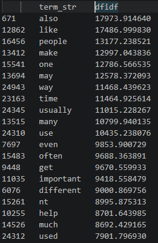

# Derived Tables

## BOW (3)

A bag-of-words representation of the CORPUS.

- UVA Box URL: https://virginia.box.com/s/v7sjlmmovgd1s0t5ztxq1bbos2apnijv
- GitHub URL for notebook used to create: https://github.com/lderos/DS-5001-Final-Project/blob/main/derivedTables.ipynb
- Delimitter: |
- Bag (expressed in terms of OHCO levels): 'doc_id'
- Number of observations: 326,807
- Columns (as delimitted names, including `n`, `tfidf`): 'doc_id', 'term_str', 'n', 'tfidf'

## DTM (3)

A represenation of the BOW as a sparse count matrix.

- UVA Box URL: https://virginia.box.com/s/yy7du52x1ib0z7iazms84doe1m2y2c4s
- UVA Box URL of BOW used to generate (if applicable): https://virginia.app.box.com/file/2205749714003
- GitHub URL for notebook used to create: https://github.com/lderos/DS-5001-Final-Project/blob/main/derivedTables.ipynb
- Delimitter: |
- Bag (expressed in terms of OHCO levels): 'doc_id'

## TFIDF (3)

A Document-Term matrix with TFIDF values.

- UVA Box URL: https://virginia.box.com/s/jruv0906xiiqvm9q68kkzwdyzs9f8j42
- UVA Box URL of DTM or BOW used to create: https://virginia.app.box.com/file/2205767118379
- GitHub URL for notebook used to create: https://github.com/lderos/DS-5001-Final-Project/blob/main/derivedTables.ipynb
- Delimitter: |
- Description of TFIDIF formula ($\LaTeX$ OK):

For each document $d$ and term $t$, the TFIDF weight is computed as:

$$ \mathrm{tfidf}(t,d) = \mathrm{tf}(t,d) \cdot \log_2\left(\frac{D}{\mathrm{df}(t)}\right) $$

where $\mathrm{tf}(t,d)$ is the raw frequency of term $t$ in document $d$, $D$ is the total number of documents in the corpus, and $\mathrm{df}(t)$ is the number of documents containing term $t$.

## Reduced and Normalized TFIDF_L2 (3)

A Document-Term matrix with L2 normalized TFIDF values.

# Models

## PCA Components (4)

- UVA Box URL: https://virginia.box.com/s/ug76bbwn02n8gpye2oyl39iclslexxg7
- UVA Box URL of the source TFIDF_L2 table: https://virginia.box.com/s/arkdty11teluaopeha3likdsdn88xlc3
- GitHub URL for notebook used to create: https://github.com/lderos/DS-5001-Final-Project/blob/main/PCAmodels.ipynb
- Delimitter: |
- Number of components: 10
- Library used to generate: scikit-learn TruncatedSVD
- Top 5 positive terms for first component: 'people' 'like' 'may' 'money' 'make'
- Top 5 negative terms for second component: 'body' 'water' 'like' 'brain' 'feel'

## PCA DCM (4)

The document-component matrix generated.

- UVA Box URL: https://virginia.box.com/s/zzw58d8tylwnplpalscl4axaixifmp00
- GitHub URL for notebook used to create: https://github.com/lderos/DS-5001-Final-Project/blob/main/PCAmodels.ipynb
- Delimitter: |

## PCA Loadings (4)

The component-term matrix generated.

- UVA Box URL: https://virginia.box.com/s/0niq4z0u394bm8lxpt1lpj8sotootrjv
- GitHub URL for notebook used to create: https://github.com/lderos/DS-5001-Final-Project/blob/main/PCAmodels.ipynb
- Delimitter: |

## PCA Visualization 1 (4)

Include a scatterplot of documents in the space created by the first two components.

Color the points based on a metadata feature associated with the documents.

Also include a scatterplot of the loadings for the same two components. (This does not need a feature mapped onto color.)

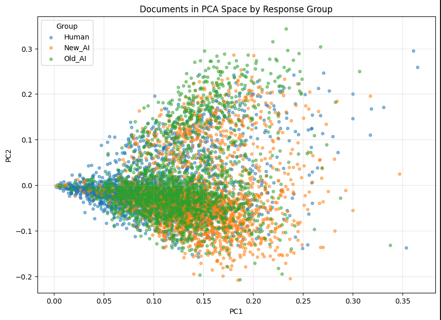

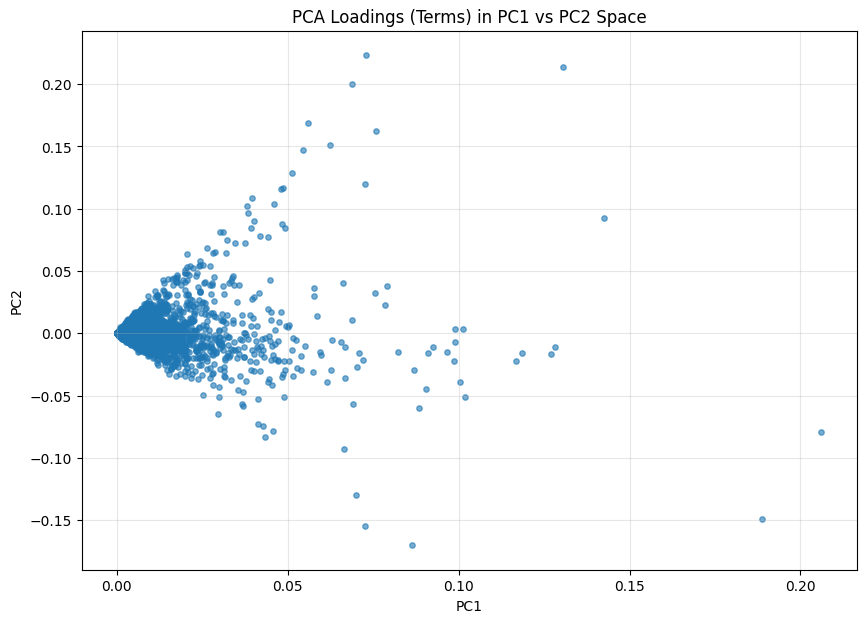

Briefly describe the nature of the polarity you see in the first component:

PC1 reflects a gradient from documents with generic or sparse term usage to documents with high concentrations of dominant, distinguishing terms. Rather than separating two opposing topics, it measures the degree of term prominence.

## PCA Visualization 2 (4)

Include a scatterplot of documents in the space created by the second two components.

Color the points based on a metadata feature associated with the documents.

Also include a scatterplot of the loadings for the same two components. (This does not need a feature mapped onto color.)

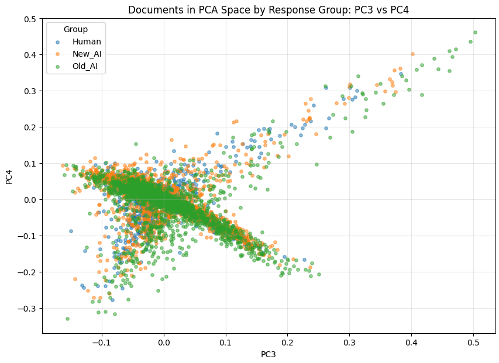

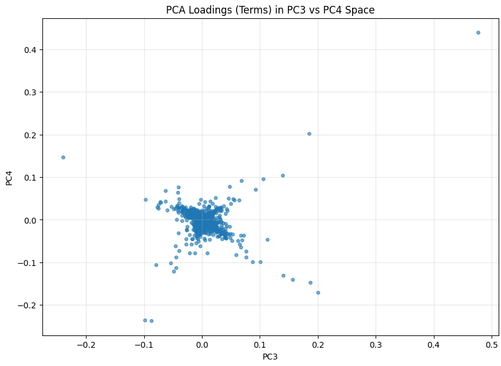

Briefly describe the nature of the polarity you see in the second component:

PC4 shows a balanced more balanced polarity, separating documents into two opposing patterns of term usage. It is difficult to determine exactly what PC4 captures, but documents with positive PC4 values emphasize one subset of terms, while those with negative values emphasize another. However, compared to earlier components, this polarity is weaker and more localized, reflecting finer-grained variation in the data rather than a dominant thematic split.

## LDA TOPIC (4)

- UVA Box URL: https://virginia.box.com/s/3c2sldqy3y329rjfeyz6d4y56aj24tvc
- UVA Box URL of count matrix used to create: https://virginia.box.com/s/r7csncr4dxl2s2ktr2xz1n4gbzt2c5dv
- GitHub URL for notebook used to create: https://github.com/lderos/DS-5001-Final-Project/blob/main/LDAmodels.ipynb
- Delimitter: |
- Libary used to compute: sklearn.decomposition.LatentDirichletAllocation
- A description of any filtering, e.g. POS (Nouns and Verbs only): Tokens were filtered using part-of-speech tagging to retain only nouns and verbs. Additionally, very short tokens (length ≤ 2) were excluded to reduce noise and improve topic coherence.
- Number of components: 5
- Any other parameters used: n_components=5, random_state=0, learning_method='batch', max_iter=20
- Top 5 words and best-guess labels for topic five topics by mean document weight:
  - T00: are, people, was, have, were
  - T01: are, people, have, money, make
  - T02: are, have, tax, money, income
  - T03: are, body, have, credit, help
  - T04: are, price, water, stock, air

## LDA THETA (4)

- UVA Box URL: https://virginia.box.com/s/pp17ygynssg4wpkucb7su100xes0hn9v
- GitHub URL for notebook used to create: https://github.com/lderos/DS-5001-Final-Project/blob/main/LDAmodels.ipynb
- Delimitter: |

## LDA PHI (4)

- UVA Box URL: https://virginia.box.com/s/fihpk5eccoaydmkpf0o3sgawmklf1oq8
- GitHub URL for notebook used to create: https://github.com/lderos/DS-5001-Final-Project/blob/main/LDAmodels.ipynb
- Delimitter: |

## LDA + PCA Visualization (4)

Apply PCA to the THETA table and plot the topics in the space opened by the first two components.

Size the points based on the mean document weight of each topic (using the THETA table).

Color the points basd on a metadata feature from the LIB table.

Provide a brief interpretation of what you see.

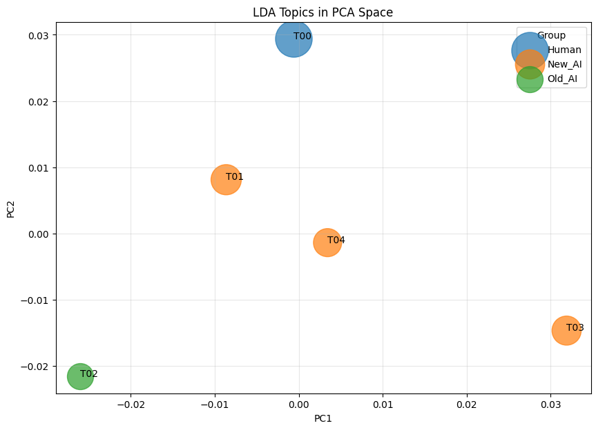

## Sentiment VOCAB_SENT (4)

Sentiment values associated with a subset of the VOCAB from a curated sentiment lexicon.

- UVA Box URL: https://virginia.box.com/s/1m4sfb7l4ui4kfadw8xb2hnx4b43m20j
- UVA Box URL for source lexicon: https://virginia.box.com/s/qlfppyym303qfd2a95fq73fkagiqiqz4
- GitHub URL for notebook used to create: https://github.com/lderos/DS-5001-Final-Project/blob/main/sentimentmodels.ipynb
- Delimitter: |

## Sentiment BOW_SENT (4)

Sentiment values from VOCAB_SENT mapped onto BOW.

- UVA Box URL: https://virginia.box.com/s/cfeppg6kgxn8ll98xgmwsthm1l17ei6z
- GitHub URL for notebook used to create: https://github.com/lderos/DS-5001-Final-Project/blob/main/sentimentmodels.ipynb
- Delimitter: |

## Sentiment DOC_SENT (4)

Computed sentiment per bag computed from BOW_SENT.

- UVA Box URL: https://virginia.box.com/s/zqzx5rhaub6ojdja81lax4uoqvnnp10z
- GitHub URL for notebook used to create: https://github.com/lderos/DS-5001-Final-Project/blob/main/sentimentmodels.ipynb
- Delimitter: |
- Document bag expressed in terms of OHCO levels: doc_id

## Sentiment Plot (4)

Plot sentiment over some metric space, such as time.

If you don't have a metric metadata features, plot sentiment over a feature of your choice.

You may use a bar chart or a line graph.

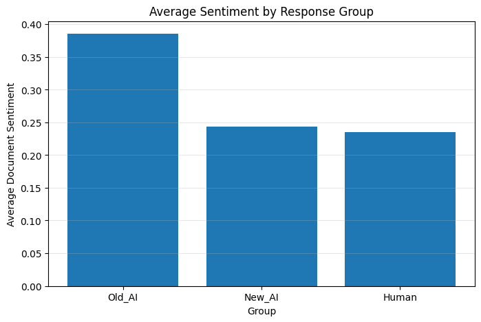

## VOCAB_W2V (4)

A table of word2vec features associated with terms in the VOCAB table.

- UVA Box URL: https://virginia.box.com/s/no62fn5twqfhl0l0ttxl37a6zjiujygv
- GitHub URL for notebook used to create: https://github.com/lderos/DS-5001-Final-Project/blob/main/W2Vmodels.ipynb
- Delimitter: |
- Document bag expressed in terms of OHCO levels: doc_id
- Number of features generated: 100
- The library used to generate the embeddings: gensim.models.Word2Vec

## Word2vec tSNE Plot (4)

Plot word embedding featues in two-dimensions using t-SNE.

Describe a cluster in the plot that captures your attention.

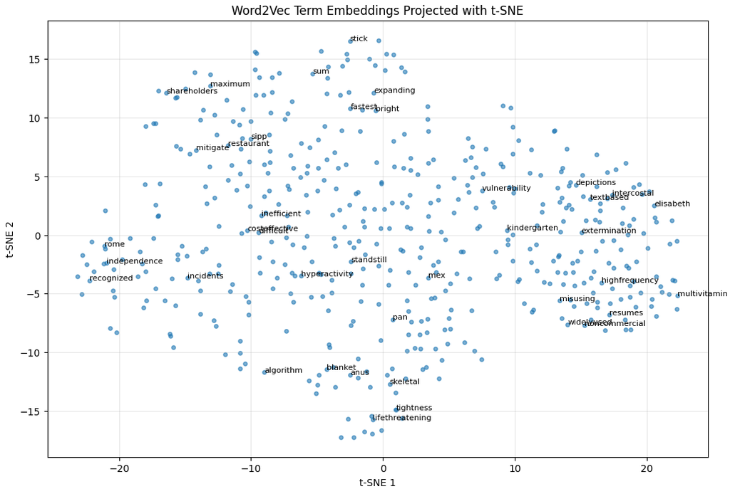

The t-SNE visualization of Word2Vec embeddings shows clusters of semantically related terms. One noticeable cluster on the right includes terms like "resumes" and "commercial," suggesting an economic and professional theme. Another region towards the middle captures a more negative word cluster with words like "inefficient" and "difficult."

# Riffs

Provde at least three visualizations that combine the preceding model data in interesting ways.

These should provide insight into how features in the LIB table are related.

The nature of this relationship is left open to you -- it may be correlation, or mutual information, or something less well defined.

In doing so, consider the following visualization types:

- Hierarchical cluster diagrams
- Heatmaps
- Scatter plots
- KDE plots
- Dispersion plots
- t-SNE plots
- etc.

## Riff 1 (5)

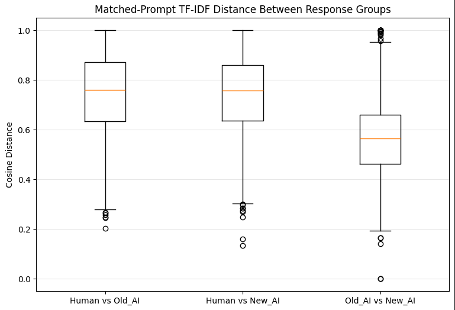

The boxplot displays the distribution of cosine distances between TF-IDF representations of responses to the same prompts, comparing linguistic similarity across Human, Old_AI, and New_AI groups. This analysis reveals that responses generated by older and newer AI models are substantially more similar to each other than to human responses. Both Human – Old AI and Human – New AI comparisons exhibit nearly identical mean distances (~0.74), indicating that newer AI models have not significantly reduced the lexical gap between AI and human-generated text. In contrast, the lower distance between Old AI and New AI (~0.56) suggests that improvements in AI models primarily refine an existing linguistic style rather than converging toward human-like language.

## Riff 2 (5)

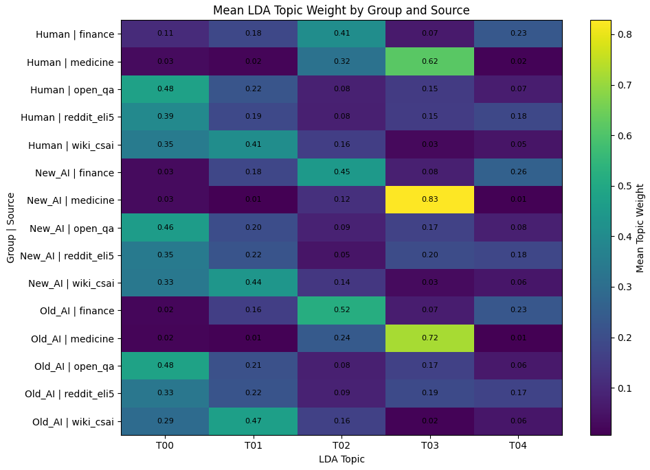

The LDA topic heatmap shows that topic distribution is primarily driven by the source domain of the question rather than the response group. However, clear differences exist between humans and AI systems. AI-generated responses exhibit less lexical variance in dominant topics, particularly in structured domains such as medicine and finance, while human responses are more evenly distributed across multiple topics. This indicates that AI systems are more focused and topically concentrated, whereas human responses use a wider range of contextual information, like the usage of filler words and going on tangents, beyond the central theme.

## Riff 3 (5)

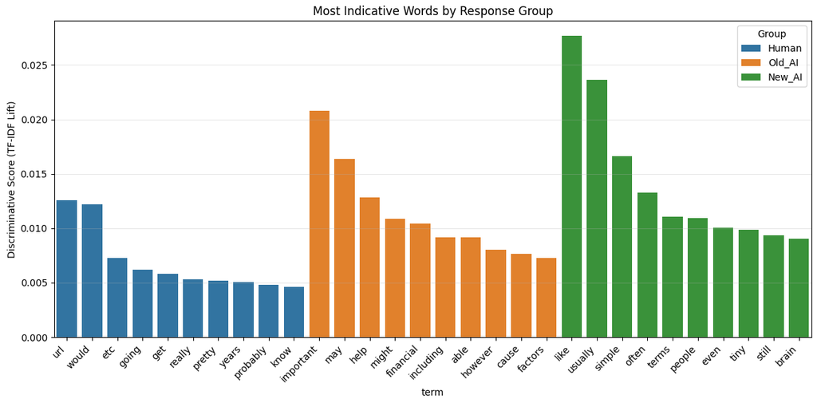

The discriminative word analysis reveals clear stylistic differences across response groups by displaying the words that most clearly identify response groups. Human responses are characterized by more conversational and informal language. Older AI responses emphasize structured, explanatory language with more formal transitions. Newer AI responses shift toward simpler and more casual phrasing. These patterns suggest that while AI systems have evolved toward less formal language, they still maintain a more standardized linguistic style compared to the variability observed in human-generated text.

# Interpretation (4)

Describe something interesting about your corpus that you discovered during the process of completing this assignment.

At a minumum, use 250 words, but you may use more. You may also add images if you'd like.

One of the most interesting discoveries from this project is that, even under a tightly controlled experimental design where Human, Old AI, and New AI responses are generated from the exact same 2,000 prompts, clear and persistent differences emerge in style, structure, and linguistic behavior across groups. The visualizations in this report show that these differences are significant as they appear across multiple modeling approaches.

The sentiment analysis provides an especially revealing insight. As shown in the bar chart, Old AI responses exhibit noticeably higher average sentiment (~0.39) compared to both New_AI (~0.24) and Human (~0.23) responses. This suggests that older AI systems tended to produce more positive and emotionally inflated language. New AI aligns more closely with human sentiment levels, indicating a shift toward a more neutral tone. This suggests that newer models are improving in emotional restraint to match a more human sentiment.

Finally, the custom “riff” visualizations help tie these findings together. The matched-prompt distance plot shows that New AI is not significantly closer to humans than Old AI, while the discriminative word analysis reveals that each group has a distinct lexical fingerprint. These results suggest that while AI systems are improving sentiment and clarity, they are not necessarily becoming more human in their underlying linguistic structure. Overall, the corpus reveals a compelling pattern. AI is evolving toward cleaner, more consistent, and more controlled language, but human responses remain more variable, context-rich, and stylistically diverse. In the end, what makes human language distinctly human goes beyond just correctness or clarity, but its unpredictability, nuance, and the subtle ways it reflects lived experience beyond any single, optimized statistical inference.